# Week 09: Regression

# 1 Overview

This lab will demonstrate how to perform a simple linear regression in R. This includes checking assumptions, fitting the linear model, interpreting and visualizing the results.

# 2 Setup

### 2.0.1 Libraries

```r
library(tidyverse)
```

### 2.0.2 Data

We will use the `trees` data which comes with R. Load the data by running the following command:

```r
data("trees")
```

`trees` contains data on the girth (DBH), height (in ft) and volume (cubic feet) of 31 black cherry trees. Run `?trees` to learn more about the data.

# 3 Lecture Outline

## 3.1 Linear Regression

- Relationship between continuous variables
- This is a predictive relationship
- i.e., with ANOVA, we could just say if the treatments were different
- Not possible to predict what a *new* treatment would do
- Linear regression does alow us to predict what a new treatment would do.
- Use scatter plots
- `geom_point()`

- ```
  Fit a "best" line through the points
  ```

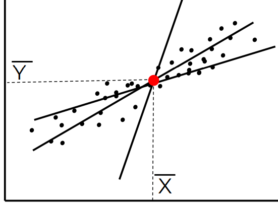

Which line is best?

- Determine “best” fit with Ordinary Least Squares (OLS)

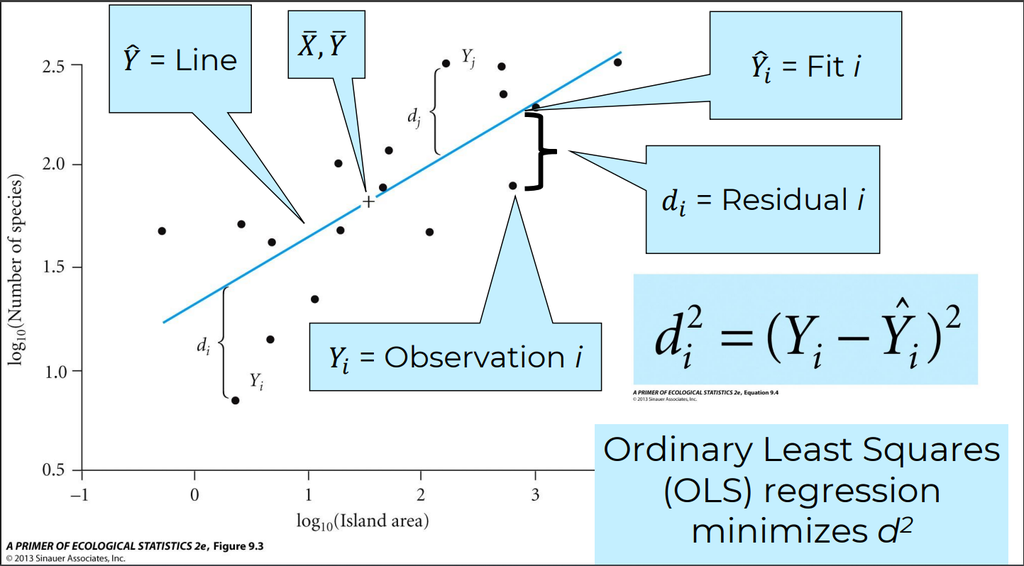

Ordinary Least Squares

- Once we have a line, is it significant? or is there a relationship?
- is my slope = 0, or $\ne$ 0?

We will be looking to see if girth (DBH) can be used as a predictor for tree height. But first, Let’s look at the full data set.

```r
names(trees)
```

```
[1] "Girth"  "Height" "Volume"
```

```r
dim(trees)
```

```
[1] 31  3
```

```r
head(trees)
```

```
  Girth Height Volume
1   8.3     70   10.3
2   8.6     65   10.3
3   8.8     63   10.2
4  10.5     72   16.4
5  10.7     81   18.8
6  10.8     83   19.7
```

Notice that the all three variables are continuous ( class = `<dbl>`) and this suggests that we will be performing a linear regression.

## 3.2 Plot data

Let’s start by plotting all of the data. `Height` is going to be our response variable, and `Girth` will be our predictor variable.

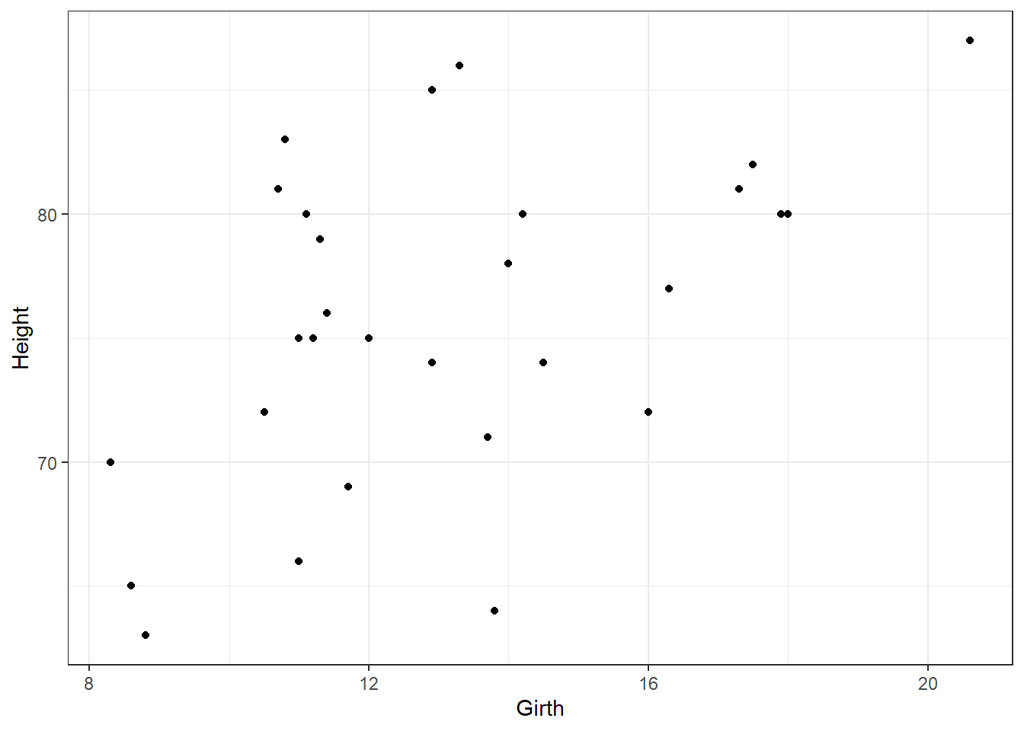

```r
ggplot(trees,
       aes(x = Girth,
           y = Height)) +
  geom_point() +
  theme_bw()
```

### 3.2.1 Questions

1. Does it appear that there is a uniform distribution of x-values (Girth)?
2. Does this look like a linear relationship to you? Why or why not?

#### 3.2.1.1 Example of non-uniform x-values

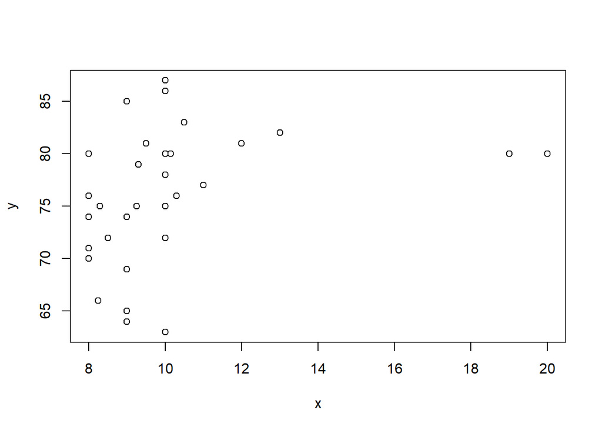

### 3.2.2 Add a line of best fit

We can also add a linear regression line using the `geom_smooth()` argument in ggplot. The default for this argument is to use a non-linear smoother, but we will be setting it to be a linear smoother using the `method = "lm` argument.

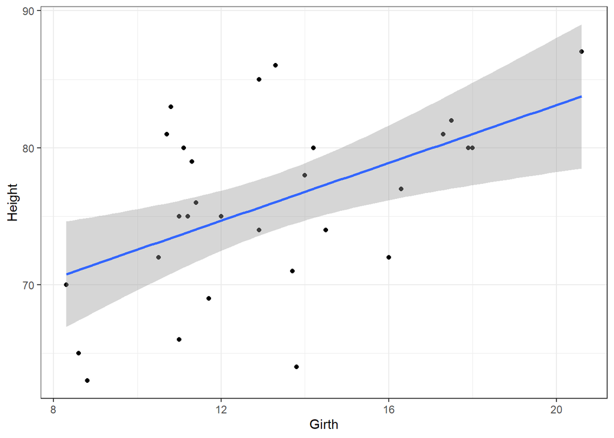

```r
ggplot(trees,
       aes(x = Girth,
           y = Height)) +
  geom_point() +
  geom_smooth(method = "lm") +
  theme_bw()
```

- It’s always a good idea to check and make sure the scatter plot looks like it is linear

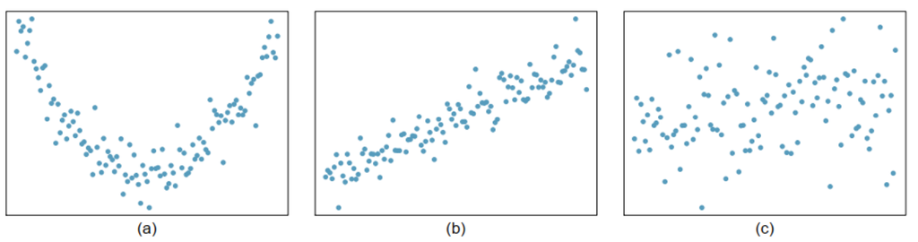

## 3.3 Equation for a linear regression

For a simple linear regression with one continous predictor, we have the following equation:

$$\hat{y} = \beta_0 + \beta_1 * x_1$$

Where $\beta_0$ is the intercept and $\beta_1$ is the regression coefficient.

## 3.4 Hypotheses for linear regression

### 3.4.1 Intercept

$$H0: \beta_0 = 0$$
$$H0: \beta_0 \ne 0$$

We have seen this a number of times at this point. Often, we are not interested in the value of the intercept coefficient per se, but we have to pick a value to compare it with and 0 is as good as any. When you perform a linear regression you should always report your findings and relate it to the null hypothesis. But since we’re not *usually* interested in this value you would avoid discussing it in detail.

### 3.4.2 Regression coefficient(s)

$$H0: \beta_1 = 0$$
$$H0: \beta_1 \ne 0$$

For the regression coefficient, the plain word interpretation for the NULL hypothesis is that “there is no relationship between x and y”. Or, in other words, the value of y does not depend on the value of x.

Likewise, the alternative hypothesis is that there is a relationship between x and y, or that the value of y does depend on the value of x.

## 3.5 Check pre-analysis assumptions

### 3.5.1 Assumptions: Normality of residuals

#### 3.5.1.1 QQ-plot

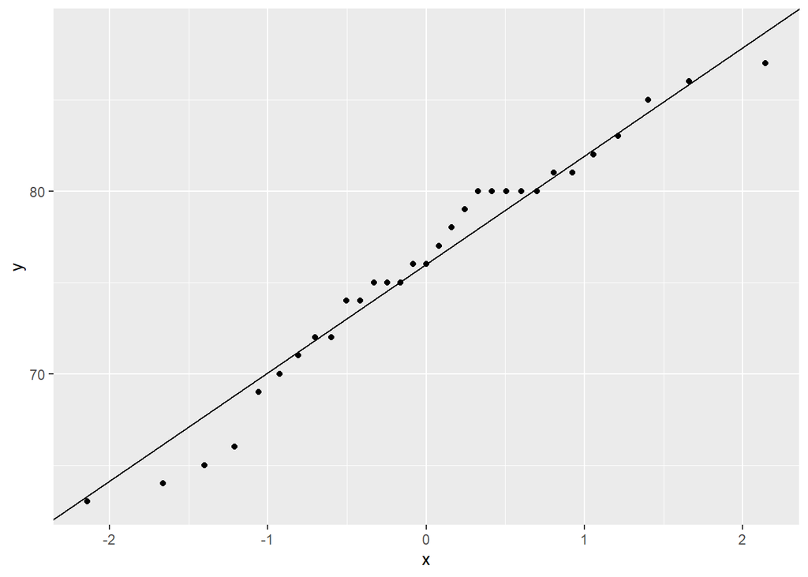

```r
ggplot(trees,
       aes(sample = Height)) +
  stat_qq()+
  stat_qq_line()
```

Most of the observations (points) fall close to the reference line, meaning that we have a normal distribution of residuals.

# 4 Fit the linear model

Let’s fit a linear model to the data.

```r
tree_lm <- lm(Height ~ Girth, data = trees)
```

### 4.0.1 Assumption: Equal variance of residuals

Before we look at the results, let’s check our post-model fit assumption with a fitted vs. residuals plot.

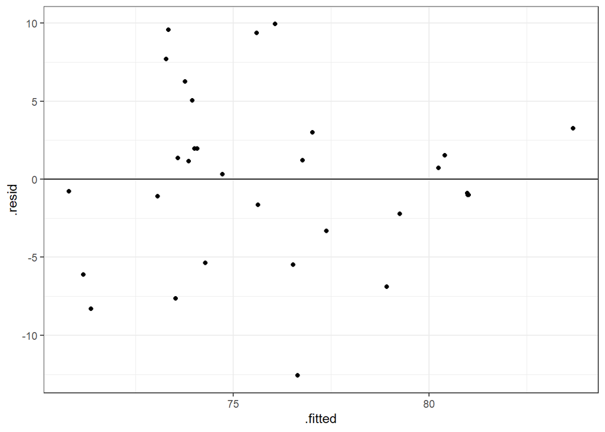

```r
ggplot(tree_lm,
       aes(x = .fitted, y = .resid)) +
    geom_point(
      position = position_jitter(
        width = 0.1,
        height = 0)) +
    geom_hline(yintercept = 0) +
  theme_bw()
```

In this plot, the absolute magnitude of the maximum and minimum y-values are approximately the same (~ -10, ~ 10), although there is one point below the -10 region. There may be slightly less variation on the right side (points are closer to the line).

#### 4.0.1.1 Examples of unequal variance

- Look for patterns L to R and Top to Bottom

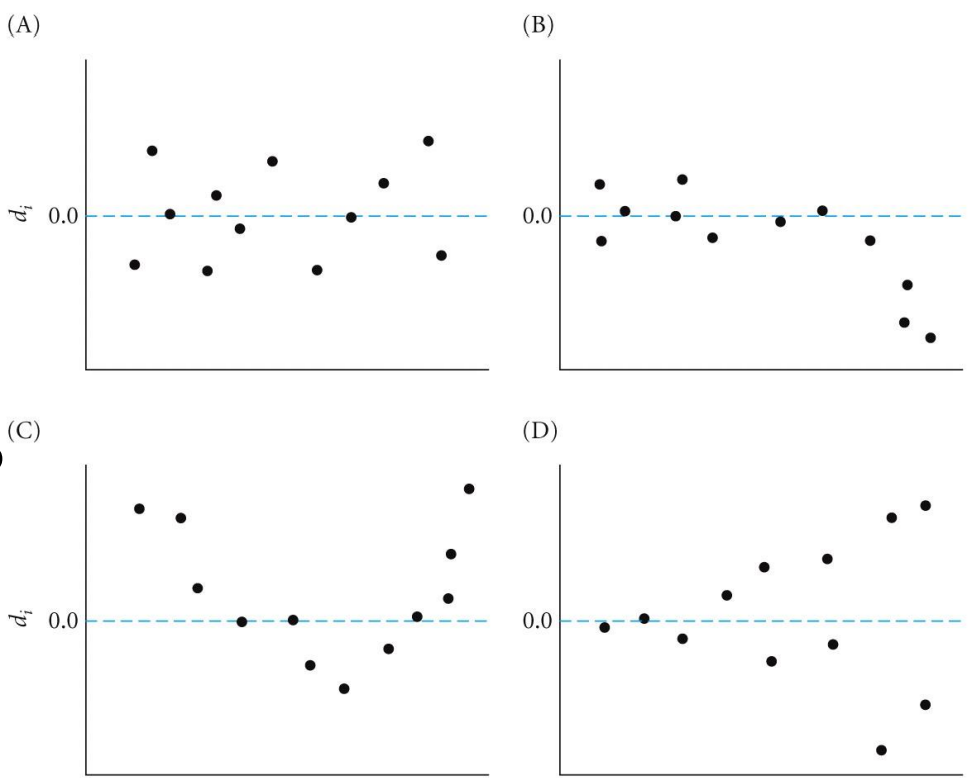

Examples of variance in residual vs. fitted plots

## 4.1 Equal variance around the regression line

- Check that the spread of the points around the line of best fit is equal

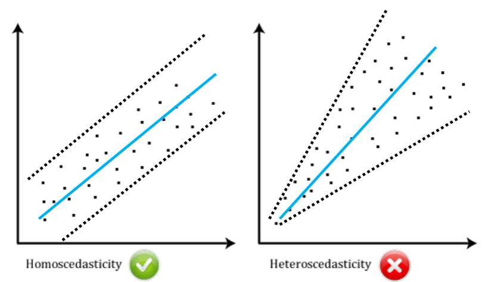

The example on the left shows that the spread of the points around the regression line (in blue) is approximately equal (i.e., parallel dashed lines). The example on the right shows unequal variance (dashed lines are not parallel).

# 5 ANOVA table

To assess the overall signifigance of our predictor variable (`Girth`) we can use the `anova()` function to print out an ANOVA tbale.

```r
anova(tree_lm)
```

```
Analysis of Variance Table

Response: Height
          Df Sum Sq Mean Sq F value   Pr(>F)
Girth      1 328.44  328.44  10.707 0.002758 **
Residuals 29 889.56   30.67
---
Signif. codes:  0 '***' 0.001 '**' 0.01 '*' 0.05 '.' 0.1 ' ' 1
```

We have a row for the predictor variable as well as the residuals (unexplained variation).

We interpret the F-value and p-value for our predictor variable in a similar way as before.

**NOTE** The ANOVA table above directly answers the null hypothesis for our regression coefficient ($\beta_1$) that we stated above. The ANOVA table **DOES NOT** have any information about our intercept coefficient ($\beta_0$). Since we are often not interested in the intercept, the ANOVA table is usually appropriate for answering our main question about the relationship between x and y.

## 5.1 ANOVA Interpretation

Remember that the hypothesis for the regression coefficient is that it is equal to zero (no relationship between x and y) or that it is not equal to 0 (there is a relationship between x and y). Therefore, our interpretation would look something like this:

> Based on our data, we can reject the null hypothesis and conclude that the value of y (Height) does depend on the value of x (Girth) in black cherry trees ($F_{1, 29}= 10.7, p = 0.003$)

## 5.2 `lm()` summary

```r
summary(tree_lm)
```

```
Call:
lm(formula = Height ~ Girth, data = trees)

Residuals:
     Min       1Q   Median       3Q      Max
-12.5816  -2.7686   0.3163   2.4728   9.9456

Coefficients:
            Estimate Std. Error t value Pr(>|t|)
(Intercept)  62.0313     4.3833  14.152 1.49e-14 ***
Girth         1.0544     0.3222   3.272  0.00276 **
---
Signif. codes:  0 '***' 0.001 '**' 0.01 '*' 0.05 '.' 0.1 ' ' 1

Residual standard error: 5.538 on 29 degrees of freedom
Multiple R-squared:  0.2697,    Adjusted R-squared:  0.2445
F-statistic: 10.71 on 1 and 29 DF,  p-value: 0.002758
```

### 5.2.1 Interpretation

We reject the null hypothesis for our intercept and conclude that it is not equal to 0 (estimate = 62, SE = 4.38, t-value = 14.152, p < 0.001)

### 5.2.2 What do the coefficients “mean”?

The intercept is the average estimated height of cherry trees when the girth is equal to 0.

The regression coefficient means that for every 1-unit increase in girth, the height of the cherry tree increases by 1.05 feet on average.

### 5.2.3 Adjusted R<sup>2</sup>

The adjusted R<sup>2</sup> value for this model is 0.2445. This means that approximately 24% of the variation in height can be explained by the measured girth. Or, more generally this model explains ~24% of the variation in our data.

### 5.2.4 Full equation for the linear model

$$\text{Height} = 62.03 + 1.05 * \text{Girth}$$

#### 5.2.4.1 Estimate values from equation

Let’s say you measure the girth of a new cherry tree and it is 19.75 inches. What would you predict the height to be?

```r
62.03 + 1.05 * 19.75
```

```
[1] 82.7675
```

Now, let’s say that you measure the height of a cherry tree as 76 feet. What do you estimate the Girth will be?

First, re-arrange the equation to have Girth be isolated on one side of the = sign:

$$\frac{(\text{Height} - 62.03)} {1.05} = \text{Girth}$$

```r
(76 - 62.03) / 1.05
```

```
[1] 13.30476
```

#### 5.2.4.2 Estimate values with `predict()`

- We can also estimate values with the `predict()` function
- Above, we estimated the height from a dbh of 19.75
- let’s do it again with `predict()`

```r
predict(tree_lm, newdata = list(Girth = 19.75))
```

```
      1
82.8551
```

#### 5.2.4.3 Fit vs. prediction

- The value that is returned by default is the “fitted” value (i.e., the value on the line in a regression)
- We can also account for uncertainty by modifying our `predict()` call

```r
predict(tree_lm,
        newdata = list(Girth = 19.75),
        interval = "prediction")
```

```
      fit      lwr      upr
1 82.8551 70.57468 95.13551
```

- Now we have a 95% Prediction interval
- In other words, if we measure the height of the tree with dbh = 19.75, we should not be surprised if the observed height is actually between 70.5 and 95.1 feet

#### 5.2.4.4 Plotting a prediction interval for the full data range

- We can add the prediction interval to our plot
- First, we need to set up our data

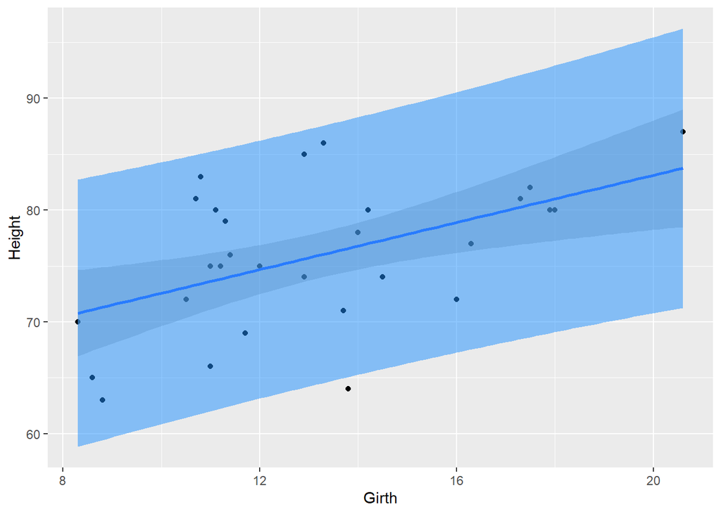

```r
girth_v <- seq(min(trees$Girth),
               max(trees$Girth),
               length.out = 100)

height_prediction <- predict(
  tree_lm,
  newdata = list(Girth = girth_v),
  interval = "prediction"
)

predict_plot_data <- data.frame(
  Girth = girth_v,
  height_prediction
) |>
  rename(Height = fit)

ggplot(trees,
       aes(x = Girth,
           y = Height)) +
  geom_point() +
  geom_smooth(method = "lm") +
  geom_ribbon(data = predict_plot_data,
              aes(ymin = lwr,
                  ymax = upr),
              fill = "dodgerblue",
              alpha = 0.5)
```

#### 5.2.4.5 Interpolation Vs. Extrapolation

- Generally only want to predict for values within the range of observed x
- This is called **Interpolation**
- It can be risky to predict values outside of the range of observed x
- This is called **extrapolation**
- For example, suppose the “real” relationship was non-linear:

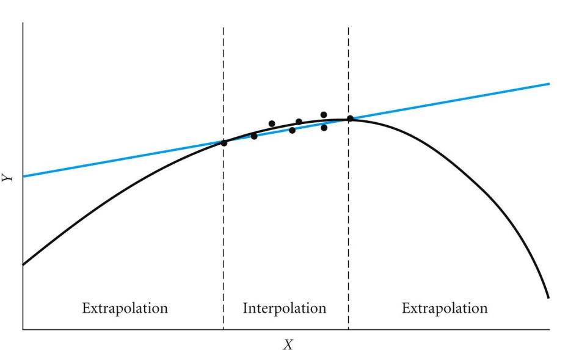

The observed data for the model is within the dashed lines. In this region, the relationship is linear (blue line). However, the “real” relationship (black curve) may be non-linear.

## 5.3 Transformations

- Let’s return to data which does not pass assumptions
- For this, we sill use the `msleep` data which is in the `ggplot2` pacakage

```r
data("msleep")
msleep
```

```
# A tibble: 83 × 11
   name   genus vore  order conservation sleep_total sleep_rem sleep_cycle awake
   <chr>  <chr> <chr> <chr> <chr>              <dbl>     <dbl>       <dbl> <dbl>
 1 Cheet… Acin… carni Carn… lc                  12.1      NA        NA      11.9
 2 Owl m… Aotus omni  Prim… <NA>                17         1.8      NA       7
 3 Mount… Aplo… herbi Rode… nt                  14.4       2.4      NA       9.6
 4 Great… Blar… omni  Sori… lc                  14.9       2.3       0.133   9.1
 5 Cow    Bos   herbi Arti… domesticated         4         0.7       0.667  20
 6 Three… Brad… herbi Pilo… <NA>                14.4       2.2       0.767   9.6
 7 North… Call… carni Carn… vu                   8.7       1.4       0.383  15.3
 8 Vespe… Calo… <NA>  Rode… <NA>                 7        NA        NA      17
 9 Dog    Canis carni Carn… domesticated        10.1       2.9       0.333  13.9
10 Roe d… Capr… herbi Arti… lc                   3        NA        NA      21
# ℹ 73 more rows
# ℹ 2 more variables: brainwt <dbl>, bodywt <dbl>
```

### 5.3.1 Raw data

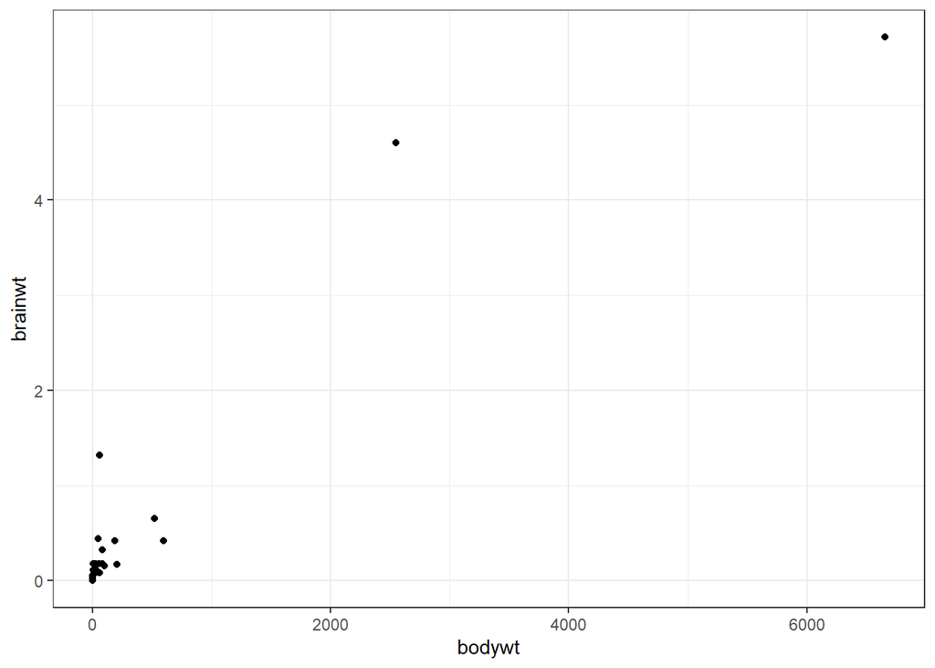

```r
ggplot(msleep,
       aes(x = bodywt,
           y = brainwt)) +
  geom_point() +
  theme_bw()
```

#### 5.3.1.1 QQ-plot

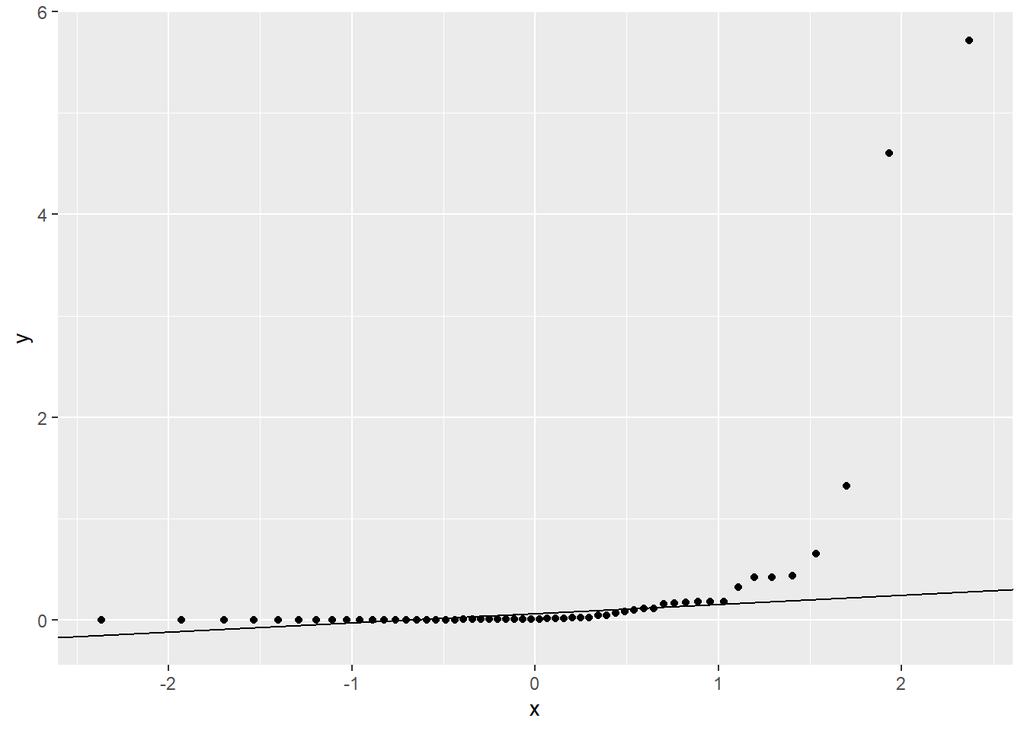

```r
ggplot(msleep,
       aes(sample = brainwt)) +
  stat_qq()+
  stat_qq_line()
```

```r
msleep_lm <- lm(brainwt ~ bodywt, data = msleep)
```

### 5.3.2 Assumption: Equal variance of residuals

Before we look at the results, let’s check our post-model fit assumption with a fitted vs. residuals plot.

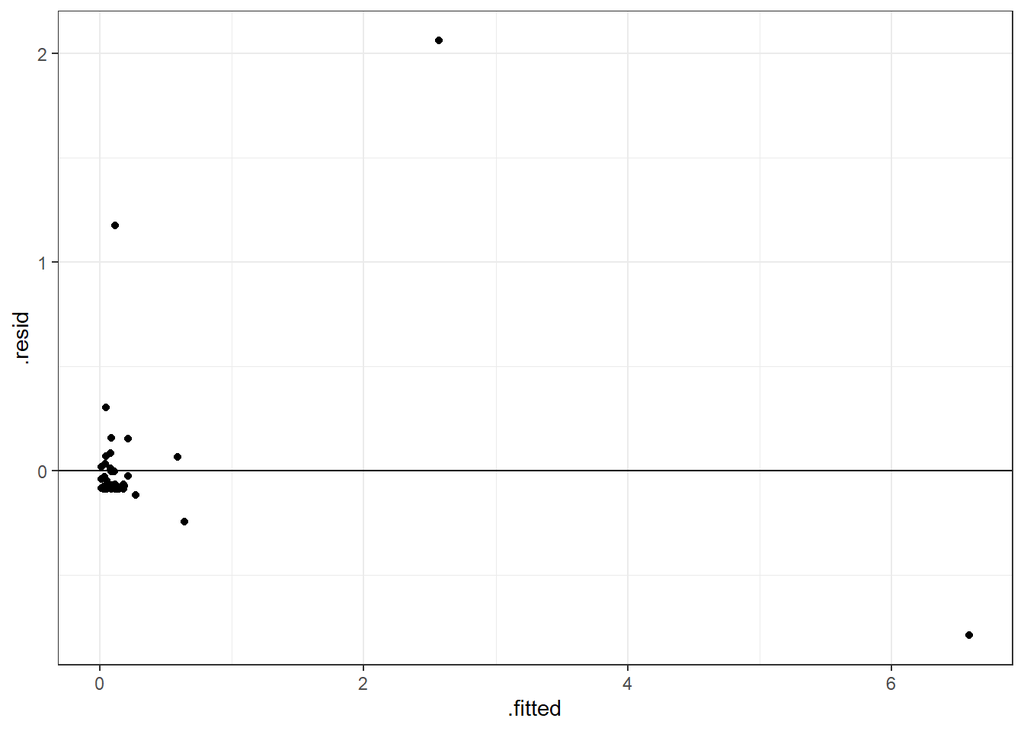

```r
ggplot(msleep_lm,
       aes(x = .fitted, y = .resid)) +
    geom_point(
      position = position_jitter(
        width = 0.1,
        height = 0)) +
    geom_hline(yintercept = 0) +
  theme_bw()
```

### 5.3.3 Log-Log transformation

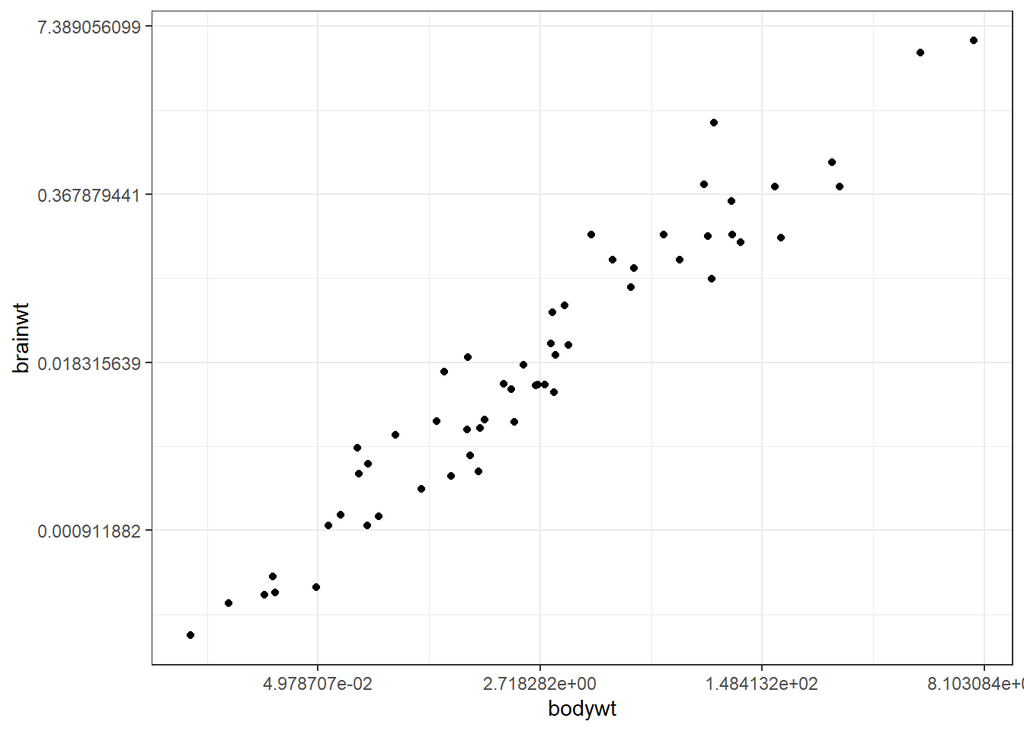

```r
ggplot(msleep,
       aes(x = bodywt,
           y = brainwt)) +
  geom_point() +
  theme_bw() +
  scale_x_continuous(trans = "log") +
  scale_y_continuous(trans = "log")
```

- notice the scales on the axes

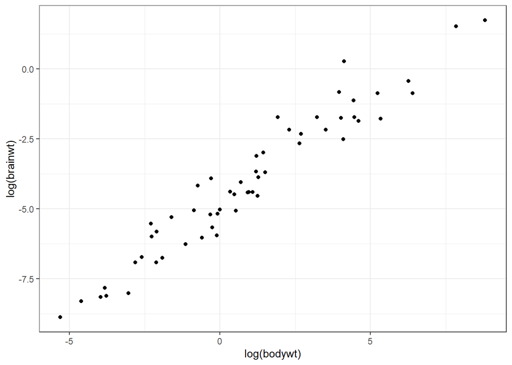

```r
ggplot(msleep,
       aes(x = log(bodywt),
           y = log(brainwt))) +
  geom_point() +
  theme_bw()
```

- Notice the name of the axes

#### 5.3.3.3 Fit the model on tranformed variables

```r
msleep_log_lm <- lm(log(brainwt) ~ log(bodywt), data = msleep)
```

#### 5.3.3.4 QQ-plot

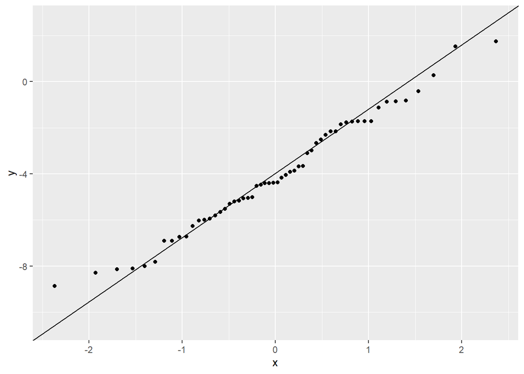

```r
ggplot(msleep,
       aes(sample = log(brainwt))) +
  stat_qq()+
  stat_qq_line()
```